# Tarea 2 Vizualización de Datos

Magister en Data Science

Rodrigo Verdugo Reyes

1/8/2022

El dataset es PartidosChile1aDiv.csv y fue obtenido desde Kaggle:

https://www.kaggle.com/clementeortuzar/resultados-primera-divisin-chile/version/6

1. Carga de Librerias
2. carga de Datos

```r
datos <- read_csv("PartidosChile1aDiv.csv")
datos <- dplyr::rename(datos,Goles_loc = HS, Goles_vis = AS)
head(datos, 10)
```

```
## # A tibble: 10 x 5
##    Date      HT               AT                        Goles_loc Goles_vis
##    <chr>     <chr>            <chr>                         <dbl>     <dbl>
##  1 21/6/2008 La Serena        Audax Italiano                    1         1
##  2 21/6/2008 Unión Española   Melipilla                         1         0
##  3 22/6/2008 O'Higgins        Universidad de Concepcion         3         3
##  4 22/6/2008 Antofagasta      Palestino                         0         3
##  5 22/6/2008 Huachipato       Cobreloa                          1         2
##  6 22/6/2008 Ñublense         Rangers                           2         2
##  7 22/6/2008 Santiago Morning Universidad Catolica              1         0
##  8 9/7/2008  Everton          Cobresal                          2         0
##  9 16/7/2008 Colo Colo        Osorno                            4         1
## 10 28/6/2008 Osorno           Huachipato                        3         1
```

Donde:

Date:Fecha en que se disputo el partido HT:Nombre Equipo Local del partido AT:Nombre Equipo Visita del partido HS:Goles del equipo Local AS:Goles del eauipo Visita

En primer lugar, manejamos los datos. Debemos considerar que las **Victorias** otorgan 3 puntos, los **Empates** 1 punto y las **Derrotas**, 0 puntos. Ademas, incluiremos una columna que represente el año.

```r
Fecha <- as.Date(datos$Date, format = '%d/%m/%Y')
Year  <- as.numeric(format(Fecha, '%Y'))

ptos_local <- dplyr::if_else(datos$Goles_loc == datos$Goles_vis,1,
                             dplyr::if_else(datos$Goles_loc>datos$Goles_vis,3,0))
ptos_visita <- dplyr::if_else(datos$Goles_loc == datos$Goles_vis,1,
                              dplyr::if_else(datos$Goles_loc<datos$Goles_vis,3,0))
resultados <- dplyr::if_else(datos$Goles_loc == datos$Goles_vis,"Empate",
                             dplyr::if_else(datos$Goles_loc>datos$Goles_vis,"Local","Visita"))
datos <- datos %>%
         add_column(Year) %>%
         add_column(ptos_local) %>%
         add_column(ptos_visita) %>%
         add_column(resultados)

head(datos,10)
```

```
## # A tibble: 10 x 9
##    Date  HT    AT    Goles_loc Goles_vis  Year ptos_local ptos_visita resultados
##    <chr> <chr> <chr>     <dbl>     <dbl> <dbl>      <dbl>       <dbl> <chr>
##  1 21/6… La S… Auda…         1         1  2008          1           1 Empate
##  2 21/6… Unió… Meli…         1         0  2008          3           0 Local
##  3 22/6… O'Hi… Univ…         3         3  2008          1           1 Empate
##  4 22/6… Anto… Pale…         0         3  2008          0           3 Visita
##  5 22/6… Huac… Cobr…         1         2  2008          0           3 Visita
##  6 22/6… Ñubl… Rang…         2         2  2008          1           1 Empate
##  7 22/6… Sant… Univ…         1         0  2008          3           0 Local
##  8 9/7/… Ever… Cobr…         2         0  2008          3           0 Local
##  9 16/7… Colo… Osor…         4         1  2008          3           0 Local
## 10 28/6… Osor… Huac…         3         1  2008          3           0 Local
```

#### **a)** *Visualizar N° de puntos obtenidos por cada equipo participante, tanto en número total de puntos como en puntos por partido*

Reordenamos los datos para ajustar la informacion a la solicitud. Buscaremos agrupar los datos por equipo, mostrando su puntaje acumulado total y como se obtuvieron (local o visita)

```r
datos_local <- datos %>%
               group_by(HT) %>%
               summarise(puntos_local = sum(ptos_local))
datos_visita <- datos %>%
                group_by(AT) %>%
                summarise(puntos_visita = sum(ptos_visita))
## Dejamos una sola tabla

equipos_local <- datos_local %>%
                  rename(equipo = HT)
equipos_visita <- datos_visita %>%
                  rename(equipo = AT)
puntos_equipos <- right_join(equipos_local,equipos_visita, by = "equipo")

puntos_equipos <- puntos_equipos %>%
  mutate(total = puntos_local+puntos_visita) %>%
  arrange(desc(total))
head(puntos_equipos,10)
```

```
## # A tibble: 10 x 4
##    equipo                    puntos_local puntos_visita total
##    <chr>                            <dbl>         <dbl> <dbl>
##  1 Universidad Catolica               438           341   779
##  2 Universidad de Chile               396           341   737
##  3 Colo Colo                          396           330   726
##  4 Unión Española                     361           287   648
##  5 O'Higgins                          362           259   621
##  6 Audax Italiano                     321           243   564
##  7 Palestino                          311           250   561
##  8 Huachipato                         335           207   542
##  9 Universidad de Concepcion          320           189   509
## 10 Iquique                            251           184   435
```

Visualizamos los puntos, acumulados por equipo.

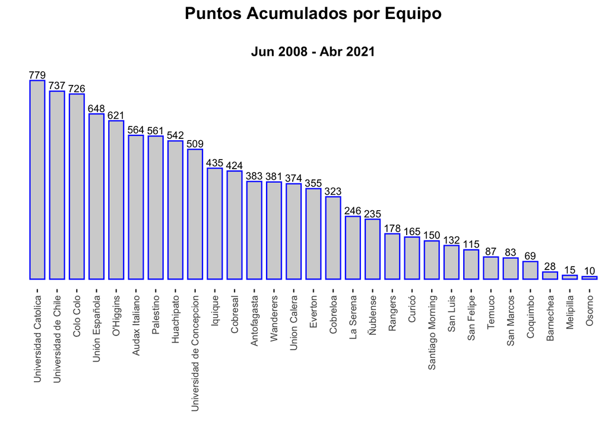

```r
viz1 <- ggplot(puntos_equipos, aes(x = reorder (equipo, -total), y = total))+
        theme(panel.background = element_blank(),
        axis.text.x = element_text(size = rel(0.9), angle = 90, hjust = 1, vjust = 0.5),
        axis.text.y = element_blank(),
        axis.ticks.y  = element_blank())+
        geom_bar(width = 0.75,colour="blue", fill= "light gray" ,stat = "identity",
           position = "dodge")+
        geom_text(aes(label = total),size = rel(3), position = position_dodge(width = 0.9),
            vjust = -0.3) +
        xlab("")+ylab("")+
        labs(title = "Puntos Acumulados por Equipo", subtitle = "Jun 2008 - Abr 2021")+
        theme(plot.title = element_text(size = 14, face = "bold", hjust = 0.5,
                                  margin = margin(b = 10)))+
        theme(plot.subtitle = element_text(size = 11, face = "bold", hjust = 0.5,
                                  margin = margin(t=10, b=10) ))


viz1
```

Podemos observar que la `Universidad Catolica` acumula la mayor cantidad de puntos en el periodo evaluado, seguido de la `Universidad de Chile` y `Colo-Colo`. A su vez, `Barnechea`, `Melipilla` y `Osorno` acumulan los mas bajos puntajes, lo que podria explicarse por su participacion esporadica en la primera division.

Tambien se nos pide poder mostrar los puntos por partido. Aca se opto por agrupar los puntos de cada equipo por el promedio acumulado, obtenidos tanto de visita como de local. Para esto, se agrega una columna promedio de puntos por equipo, para lo cual tambien necesito saber cuantos partidos jugó cada equipo.

```r
partidos_local <- datos %>%
  group_by(HT) %>%
  count(HT)
partidos_visita <- datos %>%
  group_by(AT) %>%
  count(AT)

partidos_local <- partidos_local %>%
  rename(equipo = HT) %>%
  rename (total_partidos = n)

partidos_visita <- partidos_visita %>%
  rename(equipo = AT) %>%
  rename (total_partidos = n)
total_partido <- inner_join(partidos_local, partidos_visita, by = "equipo")

total_partido <- total_partido %>%
  rename (local = total_partidos.x) %>%
  rename (visita = total_partidos.y)

puntos_partido <- total_partido%>%
  mutate(total_partidos = local + visita)

partidos_puntos <- inner_join(puntos_partido,puntos_equipos, by ="equipo")
partidos_puntos <- partidos_puntos %>%
  mutate(prom_puntos = round((total/total_partidos),2)) %>%
  arrange(desc(prom_puntos))

head(partidos_puntos, 10)
```

```
## # A tibble: 10 x 8
## # Groups:   equipo [10]
##    equipo local visita total_partidos puntos_local puntos_visita total
##    <chr>  <int>  <int>          <int>        <dbl>         <dbl> <dbl>
##  1 Unive…   207    211            418          438           341   779
##  2 Unive…   213    214            427          396           341   737
##  3 Colo …   212    209            421          396           330   726
##  4 Unión…   211    211            422          361           287   648
##  5 O'Hig…   211    207            418          362           259   621
##  6 Audax…   206    206            412          321           243   564
##  7 Pales…   204    206            410          311           250   561
##  8 Huach…   206    205            411          335           207   542
##  9 Unive…   193    192            385          320           189   509
## 10 Cobre…   124    123            247          210           113   323
## # … with 1 more variable: prom_puntos <dbl>
```

Ahora procedemos a visualizar la data arreglada. Para esto, usaremos los graficos de `Lolypop`.

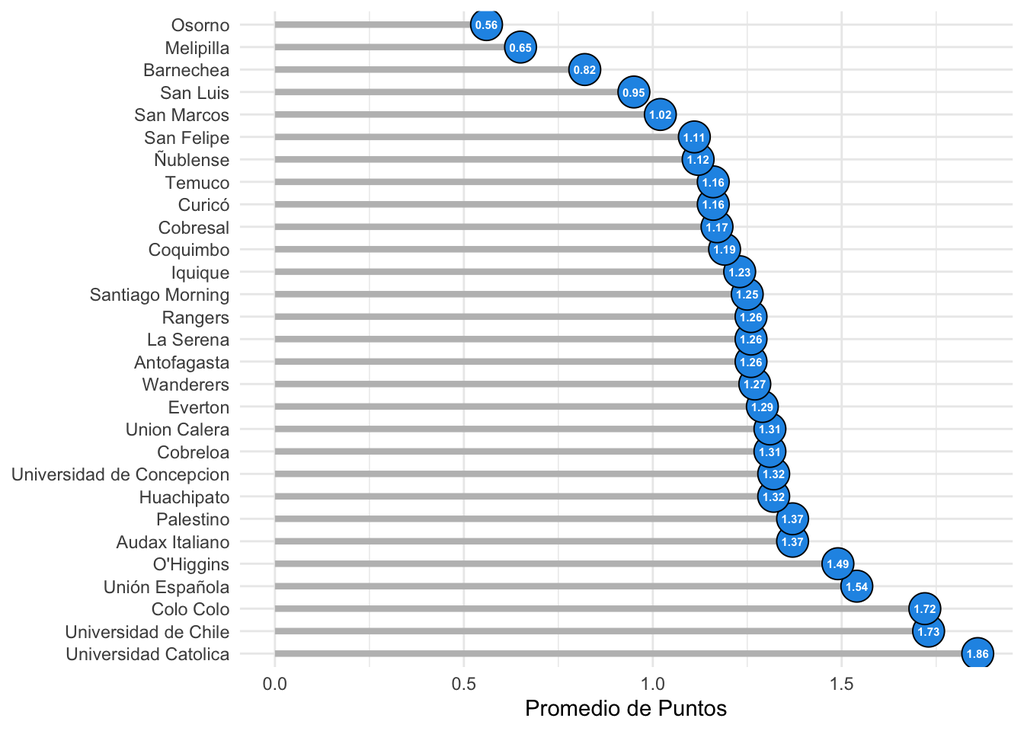

```r
viz2<- ggplot(partidos_puntos, aes(x = reorder(equipo,-prom_puntos), y =  prom_puntos)) +
  geom_segment(aes(x = reorder(equipo, -prom_puntos), xend = equipo, y = 0, yend = prom_puntos),
               color = "gray", lwd =1.5) +
  geom_point(size = 7, pch = 21, bg = 4, col = 1)+
  geom_text(aes(label = prom_puntos), color = "white", fontface = "bold",size = 2) +
  scale_x_discrete(NULL) +
  scale_y_continuous("Promedio de Puntos") +
  coord_flip()  +
  theme_minimal()

viz2
```

Nuevamente, vemos que el equipo que ha sido capaz de acumular un mayor promedio de puntos por partido, es la Universidad Catolica, con 1.86 puntos por partido, seguido de la Universidad de Chile, con 1.73, y Colo-Colo, con 1.72 puntos.

### **b)** *Diferencias en la distribución del n° de goles convertidos por el equipo local y visitante.*

Manejaremos el dato de tal forma que podamos agrupar a los equipos y ordenarlos en funcion de sus goles convertidos como local y como visitante.

```r
datos_goles_local <- datos %>%
  group_by(HT) %>%
  summarise(sum(Goles_loc)) %>%
  rename(equipo = HT)
datos_goles_visita <- datos %>%
  group_by(AT) %>%
  summarise(sum(Goles_vis)) %>%
  rename(equipo = AT)
total_goles <- inner_join(datos_goles_local,datos_goles_visita, by = "equipo") %>%
  rename(Goles_local = `sum(Goles_loc)`) %>%
  rename(Goles_visita =`sum(Goles_vis)`) %>%
  mutate(Goles_total = Goles_local+Goles_visita)

head(total_goles,10)
```

```
## # A tibble: 10 x 4
##    equipo         Goles_local Goles_visita Goles_total
##    <chr>                <dbl>        <dbl>       <dbl>
##  1 Antofagasta            198          181         379
##  2 Audax Italiano         324          283         607
##  3 Barnechea               15           14          29
##  4 Cobreloa               205          132         337
##  5 Cobresal               279          184         463
##  6 Colo Colo              380          320         700
##  7 Coquimbo                36           26          62
##  8 Curicó                 101           64         165
##  9 Everton                189          147         336
## 10 Huachipato             307          261         568
```

Procedemos a visualizar la data. Para esto, usaremos un grafico de Dumbell que nos permita ver los goles local y los goles visita convertidos por cada equipo en el periodo observado.

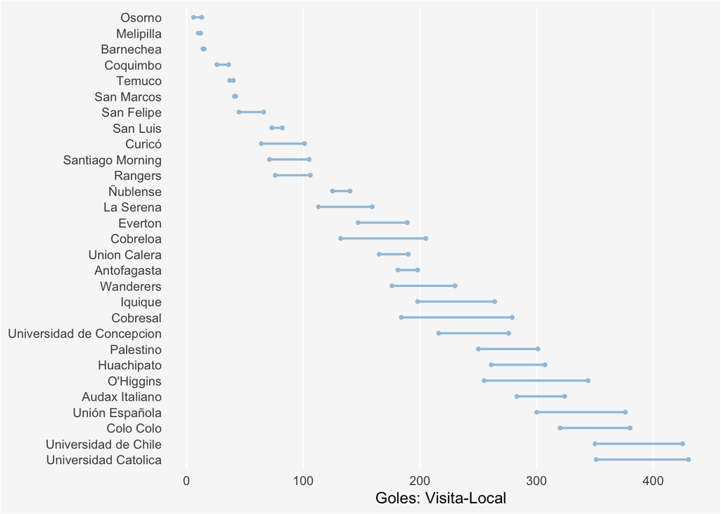

```r
viz3 <- ggplot(total_goles,aes(x = Goles_visita ,xend = Goles_local, y = reorder(equipo, -Goles_total)))+
        geom_dumbbell (color="#a3c4dc", size=0.75, point.colour.l="#0e668b") +
        theme(plot.title = element_text(hjust=0.5, face="bold"),
        plot.background=element_rect(fill="#f7f7f7"),
        panel.background=element_rect(fill="#f7f7f7"),
        panel.grid.minor=element_blank(),
        panel.grid.major.y=element_blank(),
        panel.grid.major.x=element_line(),
        axis.ticks=element_blank(),
        legend.position="top",
        panel.border=element_blank())+
        scale_x_continuous("Goles: Visita-Local") +
        scale_y_discrete(NULL)

viz3
```

Sin embargo, la idea es ver la distribucion de goles Local y Goles visitas. Si bien en este grafico nos damos cuenta que los goles acumulados de local son mas que los de visita (lo cual resulta obvio), tambien podriamos visualizar los goles como un todo.

Como el proposito es poder visualizar la distribucion de goles de cada tipo (local o visita), reordenaremos los datos para poder optar por una visualizacion apropiada.

```r
count(total_goles, "Goles_local")
```

```
## # A tibble: 1 x 2
##   `"Goles_local"`     n
##   <chr>           <int>
## 1 Goles_local        29
```

```r
## generamos una columna de 29 datos (Goles Local), y le asignamos esos datos.
## vectorizamos Goles local y Goles de Visita
local_score <- data.frame(Tipo_Gol =c(rep("Goles Local", 29)))
goles1 <- data.frame(goles =(total_goles$Goles_local))
local_score <- bind_cols(local_score, goles1)

Visit_score <- data.frame(Tipo_Gol =c(rep("Goles Visita", 29)))
goles2 <- data.frame(goles =(total_goles$Goles_visita))
Visit_score <- bind_cols(Visit_score, goles2)
scores <- local_score %>%
  add_row(Visit_score)
head(scores,10)
```

```
##       Tipo_Gol goles
## 1  Goles Local   198
## 2  Goles Local   324
## 3  Goles Local    15
## 4  Goles Local   205
## 5  Goles Local   279
## 6  Goles Local   380
## 7  Goles Local    36
## 8  Goles Local   101
## 9  Goles Local   189
## 10 Goles Local   307
```

Ahora, realizamos una visualizacion de ambos grupos de goles (*local* y *visita*). Usaremos una combinacion de Boxplot y Violin plot para poder ver el rango de totalidad de goles, y donde existe una mayor densidad en cada grupo.

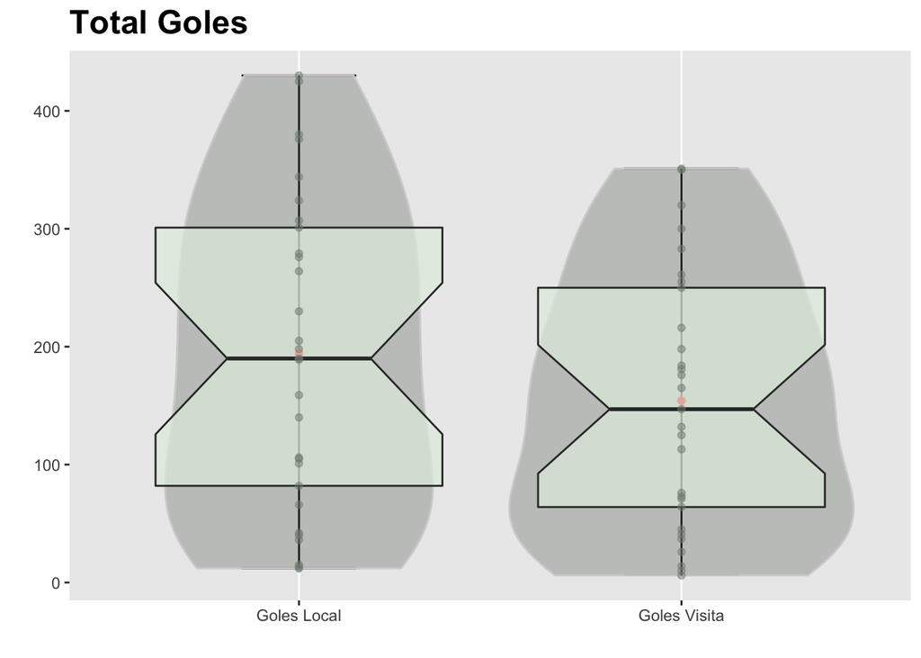

```r
viz3.5 <- ggplot(scores, aes(x = Tipo_Gol, y = goles, fill = Tipo_Gol)) +
  stat_boxplot(geom = "errorbar", width = 0.3, color = "black")+
  geom_violin(alpha = 0.4,
              colour = "lightgray", fill = "#838B83") +
  theme(legend.position = "center",
  plot.title = element_text(size = 18, face = "bold"),
  panel.grid.minor=element_blank(),
  panel.grid.major.y= element_blank(),
  panel.grid.major.x=element_line())  +
  labs(x="", y="", title = "Total Goles")+
  stat_summary(fun = "mean",  geom = "point", color = "red")+
  geom_boxplot(notch = TRUE, aes(fill = Tipo_Gol ), fill = "#E0EEE0", alpha = 0.7)+
  scale_color_viridis(option = "A") +
  geom_point(alpha = 0.5, colour="#838B83")

viz3.5
```

Como es de suponer, se observa una mayor cantidad de goles convertidos de local que de visita. El violin plot muestra que la distribucion es mas estable en los goles converstidos de local, mientras que es mas densa en la base (es decir, menos goles convertidos) para los goles convertidos de visita.

### **c)** *Diferencias en la distribución del n° de goles del equipo ganador y perdedor.*

```r
gol_ganador_local <- datos %>%
  filter(resultados == "Local")
gol_ganador_local <- data.frame(goles_ganador = (gol_ganador_local$Goles_loc))
gol_ganador_visita <- datos %>%
  filter(resultados == "Visita")
gol_ganador_visita <- data.frame(goles_ganador = (gol_ganador_visita$Goles_vis))
count(gol_ganador_local,"goles_ganador" )
```

```
##   "goles_ganador"    n
## 1   goles_ganador 1633
```

```r
count(gol_ganador_visita,"goles_ganador" )
```

```
##   "goles_ganador"    n
## 1   goles_ganador 1050
```

```r
#vectorizamos y creamos DF

ganador_local <- data.frame(score = c(rep("Goles ganador", 1633)))
goles3 <- data.frame(goles =(gol_ganador_local$goles_ganador))
ganador_local <- bind_cols(ganador_local,goles3)
ganador_visita <- data.frame(score = c(rep("Goles ganador", 1050)))
goles4 <- data.frame(goles = (gol_ganador_visita$goles_ganador))
ganador_visita <- bind_cols(ganador_visita,goles4)
score_ganadores <- ganador_local %>%
  add_row(ganador_visita)

## Lo mismo, pero para los perdedores

gol_perdedor_visita <- datos %>%
  filter(resultados == "Local")
gol_perdedor_visita <- data.frame(score = (gol_perdedor_visita$Goles_vis))
gol_perdedor_local <- datos %>%
  filter(resultados == "Visita")
gol_perdedor_local<- data.frame(score = (gol_perdedor_local$Goles_loc))

###armo df perdedores local
perdedor_local <- data.frame (score = c(rep("Goles perdedor", 1050)))
goles5 <- data.frame(goles = (gol_perdedor_local$score))
perdedor_local <- bind_cols(perdedor_local,goles5)
###armo df perdedores visita
perdedor_visita <- data.frame (score = c(rep("Goles perdedor", 1633)))
goles6 <- data.frame(goles = (gol_perdedor_visita$score))
perdedor_visita <- bind_cols(perdedor_visita,goles6)
###armo df con todos los goles, 2 columnas
score <- score_ganadores %>%
  add_row(perdedor_local) %>%
  add_row(perdedor_visita)

head(score, 10)
```

```
##            score goles
## 1  Goles ganador     1
## 2  Goles ganador     1
## 3  Goles ganador     2
## 4  Goles ganador     4
## 5  Goles ganador     3
## 6  Goles ganador     3
## 7  Goles ganador     2
## 8  Goles ganador     2
## 9  Goles ganador     2
## 10 Goles ganador     1
```

Ahora, visualizamos esta distribucion. Usaremos un boxplot

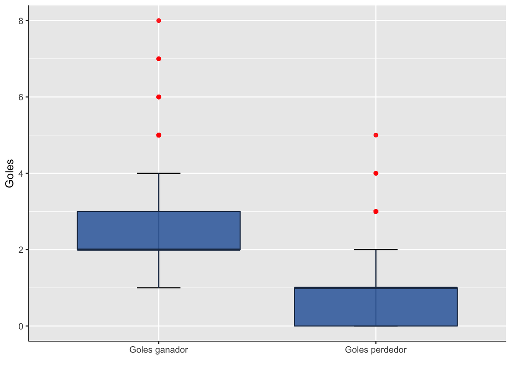

```r
viz4 <- ggplot(score, aes(x = score, y = goles)) +
  stat_boxplot(geom = "errorbar", width = 0.2)+
  geom_boxplot(fill = "#4271AE", colour = "#1F3552",
               alpha = 0.9, outlier.colour = "red")+
  scale_y_continuous(name = "Goles" ) +
  scale_x_discrete(element_blank())+
  theme(axis.line = element_line(colour = "black",
                                 size = 0.25))

viz4
```

Se observa una notoria diferencia entre ambos grupos de goles. Los goles perdedor incluyen el 0, lo cual es la condicion *sine qua non* para perder un partido. Llama la atencion que existan partidos con un alto numero de goles para los perdedores, como se observa en los valores outlier de `Goles perdedor`. Al buscar que partido fue, observamos que el 25-01-2010, Audax Italiano cae por 5 goles contra 6 frente a Ñublense. El partido donde se convirtieron mas `Goles ganador`, ocurrio el 24-01-2016, donde la **Universidad de Chile** le convierte 8 goles a **O’Higgins**

### **d**) *¿Cómo varían estas distribuciones en el período de años considerados?*

Para visualizar esta informacion, usaremos un grafico Dumbell, para ver como se distribuyen los goles a traves de los años.

En primera instancia, ordenaremos la data.

```r
year_score_local <- datos %>%
  group_by(Year) %>%
  summarise(goles_local = sum(Goles_loc))
year_score_visita <- datos %>%
  group_by(Year) %>%
  summarise(goles_visita = sum(Goles_vis))
year_score <- inner_join(year_score_local, year_score_visita, by =  "Year")
head(year_score,10)
```

```
## # A tibble: 10 x 3
##     Year goles_local goles_visita
##    <dbl>       <dbl>        <dbl>
##  1  2008         297          253
##  2  2009         494          383
##  3  2010         526          377
##  4  2011         558          433
##  5  2012         540          405
##  6  2013         457          403
##  7  2014         478          373
##  8  2015         442          368
##  9  2016         381          321
## 10  2017         335          266
```

Procedemos a realizar la visualizacion.

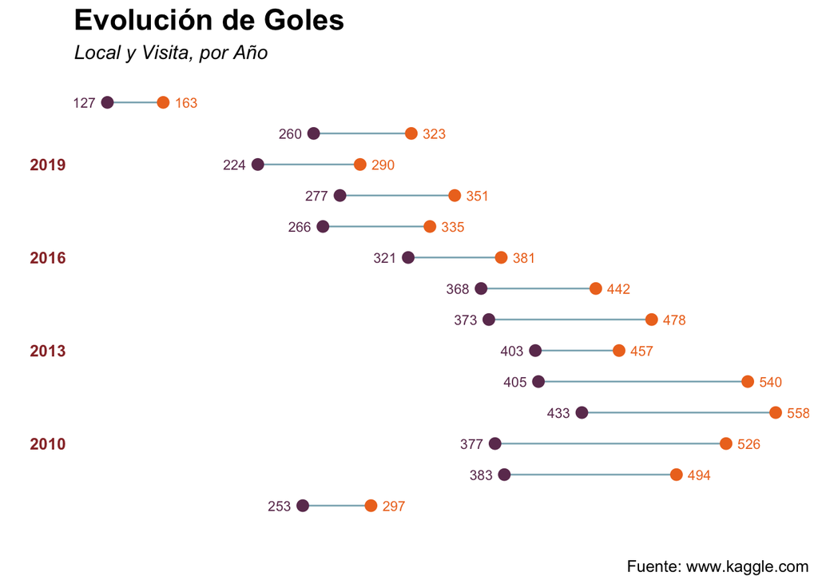

```r
theme_clean <- theme_bw(base_family="") +
  theme(legend.position = "top",
        legend.title = element_text(size = 10),
        legend.text = element_text(size = 10),
        plot.title = element_text(size = 18, face = "bold"),
        plot.subtitle = element_text(size = 12, face = "italic", margin = margin(b=12)),
        plot.caption = element_text(size = 10),
        panel.grid.major = element_blank(),
        panel.grid.minor = element_blank(),
        panel.border = element_blank(),
        axis.ticks=element_blank(),
        axis.text.x = element_blank(),
        axis.text.y = (element_text(color="#993333", size=10, face="bold")))



theme_set(theme_clean)
viz5 <-   ggplot(year_score, aes(y = Year, x= goles_local, xend = goles_visita))+
          geom_dumbbell (size_x = 3, size_xend = 3, color="#8AB0BD",
                 colour_x = "#EE7523", colour_xend = "#6D3A5D",
                 dot_guide=FALSE) +
          geom_text(color="#6D3A5D", size=3, hjust=1.5,
                  aes(x=goles_visita, label=goles_visita)) +
          geom_text(color="#EE7523", size=3, hjust= -0.5,
                  aes(x=goles_local, label=goles_local)) +
          labs(x="", y="",
              title = "Evolución de Goles",
              subtitle = "Local y Visita, por Año",
              caption = "Fuente: www.kaggle.com")

viz5
```

Podemos observar que tanto los goles convertidos como local, como aquellos convertidos de visita, tuvieron su peak en el año 2011 y despues comienzan a bajar. Los años 2008 y 2021 no representan la totalidad de dichos periodos, por lo que se ven subrepresentados en el grafico.

### **e**) *Para los partidos que terminan empatados, ¿cuántos goles convierte cada equipo?*

En este caso, filtraremos los datos por empates tanto local como visita, y agruparemos por el promedio obtenido por equipo.

```r
empate_local <- datos %>%
  filter(resultados == "Empate") %>%
  group_by(equipo = HT) %>%
  summarise(gol = Goles_loc)
empate_visita <- datos %>%
  filter(resultados == "Empate") %>%
  group_by(equipo = AT) %>%
  summarise(gol = Goles_vis)
datos_empate <- imap_dfr(empate_local,~as.data.frame(c(empate_visita)))
empate <- datos_empate %>%
  group_by(equipo) %>%
  summarise(goles = round(mean(gol),2))
head(datos_empate)
```

```
##        equipo gol
## 1 Antofagasta   0
## 2 Antofagasta   0
## 3 Antofagasta   0
## 4 Antofagasta   2
## 5 Antofagasta   3
## 6 Antofagasta   1
```

Visualizaremos usando density plot de la libreria `ggridges`.

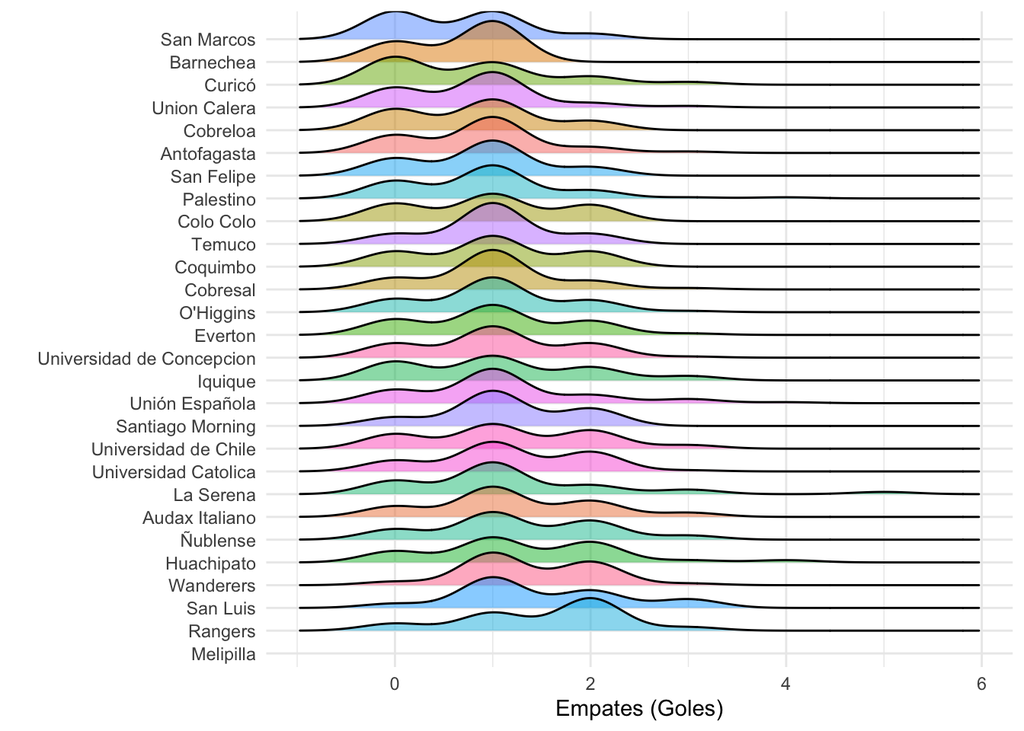

```r
  viz6 <- ggplot(datos_empate, aes(x = gol, y = reorder(equipo,-gol))) +
                   geom_density_ridges(aes(fill=equipo), alpha= 0.5, show.legend = FALSE)+
                    labs(x = "Empates (Goles)",color = "blue", y = "", )+
                  theme(legend.position = NULL,
                        panel.grid.major = element_blank(),
                        panel.grid.minor = element_blank(),)+
                   theme_minimal()

  viz6
```

Vemos que en general, la mayoria de los empates se producen a 1 gol. Melipilla no registra empates, y Rangers presenta una mayor cantidad de empates a 2 goles.

### *f)* **Bonus: Si un equipo gana un partido, qué probabilidad existe de que el siguiente gane, empate o pierda.**

Para evaluar estas probabilidades, contaremos las oportunidades en que cada equipo gana y pierde, ya sea como local o visita, ademas de las veces que empata.

```r
#contar veces que ganan
gana_local <- datos %>%
              filter(resultados == "Local") %>%
              count(resultados == "Local")
gana_visita <-datos %>%
              filter(resultados == "Visita") %>%
              count(resultados == "Visita")
empates_local     <-datos %>%
              filter(resultados == "Empate") %>%
              count(resultados == "Empate")
Resultado_ganan <- c(gana_local$n, gana_visita$n, empates_local$n) ##Resultados de local

## contar veces que pierden

pierde_local <- datos %>%
              filter(resultados == "Visita") %>%
              count(resultados == "Visita")
pierde_visita <-datos %>%
              filter(resultados == "Local") %>%
              count(resultados == "Local")
empates_visita     <-datos %>%
              filter(resultados == "Empate") %>%
              count(resultados == "Empate")

Resultado_pierden <- c(pierde_local$n, pierde_visita$n, empates_visita$n) ##Resultados de visita

Total_resultados <- gana_local$n+gana_visita$n+pierde_local$n+pierde_visita$n+empates_local$n+empates_visita$n

P_g <- (gana_local$n+gana_visita$n)/Total_resultados     ##Probabilidad de  ganar
P_p <- (pierde_local$n+pierde_visita$n)/Total_resultados  ## Probabilidad de perder
P_e <- (empates_local$n+empates_visita$n)/Total_resultados ## Probabilidad de empatar

##Probabilidades independientes
## P(p|g) = P(g|g)
P_p_g <-  P_g*P_p
##Probabilidad de empatar dado que gana
P_e_g <- P_g*P_e
P_p_g
```

```
## [1] 0.1391688
```

```r
P_e_g
```

```
## [1] 0.09471573
```

Se aplica probabilidad condicional conociendo el numero de casos totales de cada evento, tomados de forma independiente. Se considera ademas que cada partido no condiciona el resultado siguiente, es decir, son independientes. Bajo esta logica, la posibilidad de ganar luego de perder es igual a la de perder luego de ganar (14%), y la probabilidad de empatar es de 9.5%.